# Data Visualization with Esquisse

## Esquisse Package

```r
# install.packages("esquisse")
library(esquisse)
```

## Esquisse Package

The [`esquisse` package](https://cran.r-project.org/web/packages/esquisse/vignettes/get-started.html) is helpful for getting used to creating plots in R.

It is an interactive tool to help you in RStudio.

It’s super **nifty**!

[figure not shown]

## First, get some data.

We can use the CO heat-related ER visits dataset. This dataset contains information about the number and rate of visits for heat-related illness to Emergency rooms in Colorado from 2011-2022, adjusted for age.

```r
er <-
  read_csv("https://jhudatascience.org/intro_to_r/data/CO_ER_heat_visits.csv")

head(er)
```

```
## # A tibble: 6 × 6
##   county  rate lower95cl upper95cl visits  year
##   <chr>  <dbl>     <dbl>     <dbl>  <dbl> <dbl>
## 1 Adams   6.73     NA         9.24     29  2011
## 2 Adams   4.84      2.85     NA        23  2012
## 3 Adams   6.84      4.36      9.31     31  2013
## 4 Adams   3.08      1.71      4.85     15  2014
## 5 Adams   3.36      1.89      5.23     16  2015
## 6 Adams   8.85      6.12     11.6      42  2016
```

## Starting a plot

Using the `esquisser()` function you can start creating a plot for a `data.frame` or `tibble`. That’s it!

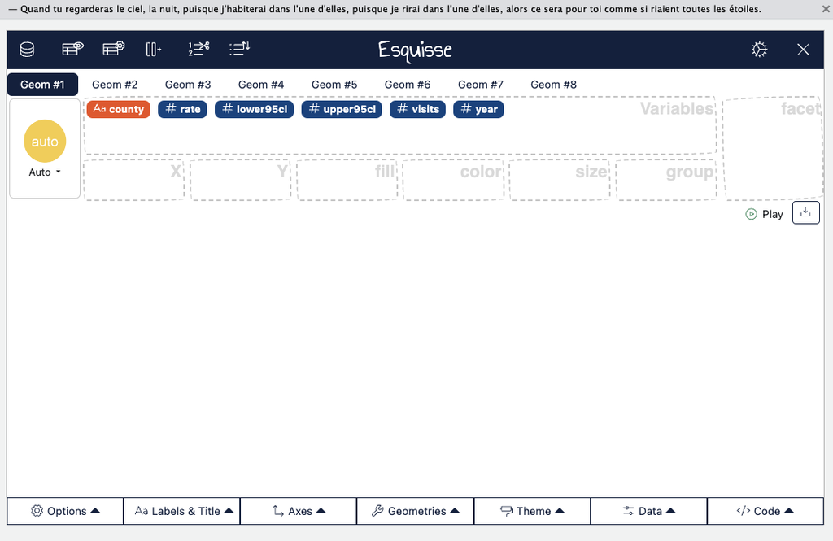

```r
esquisser(er)
```

## Show the plot in the browser

```r
esquisse::esquisser(er, viewer = "browser")
```

## Select Variables

To select variables you can drag and drop variables to the respective axis that you would like the variable to be plotted on.

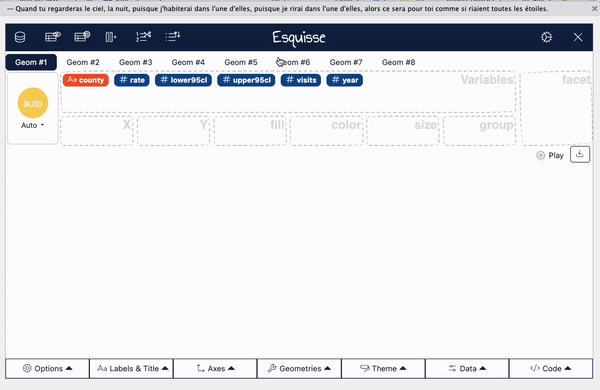

## Find code

To select variables you can drag and drop variables to the respective axis that you would like the variable to be plotted on.

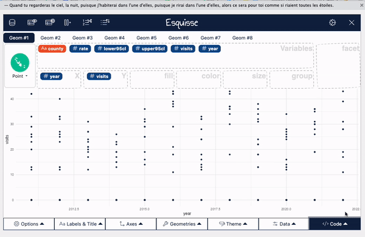

## Change plot type

`esquisse` automatically assumes a plot type, but you might want to change this.

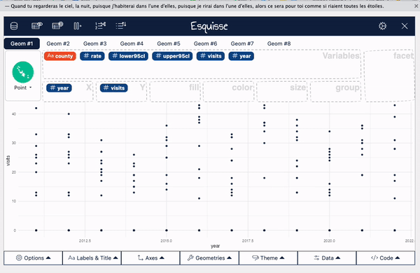

## Add Facets

Facets create multiple plots based on the different values of a variable.

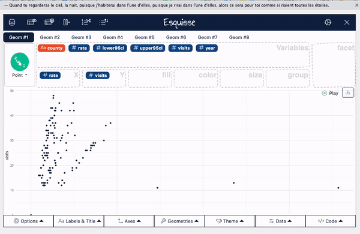

## Add size

Sometimes it is useful to change the way points are plotted so that size represents a variable. This can especially be helpful if you need your plot to be black and white.

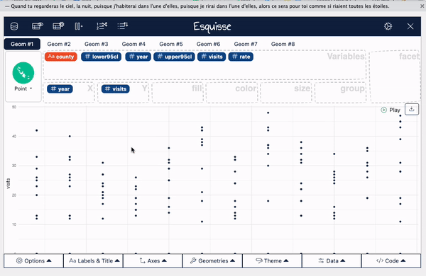

## Add color

For plots with points use the color region to change coloring according to a variable. (use “fill” for bar plots)

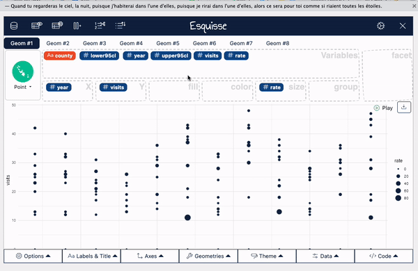

## Appearance

You can change the overall appearance with “Geometries” and “Theme”.

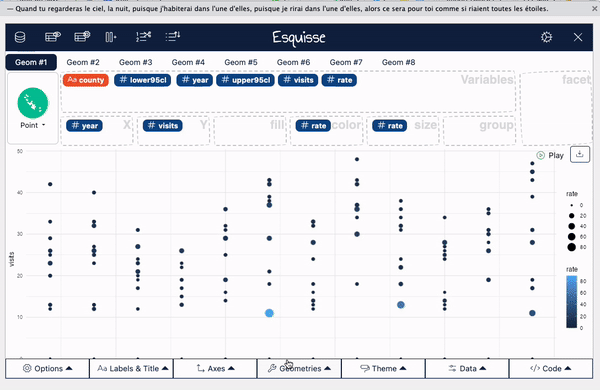

## Change titles

To change titles on your plot, use the “Labels & Titles” tab.

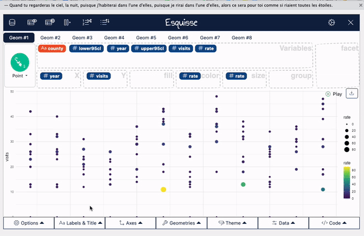

## View data

You can also easily view data

[figure not shown]

## Interrupting Esquisse

You’ll need to “interrupt” Esquisse to launch it with a new dataset.

Use the stop button or press ctrl+c to stop the Esquisse app.

*If you don’t see the stop button, you need to resize your window.*

[figure not shown]

## Wide & Long Data?

Let’s look at why we might want long data using Esquisse.

```r
library(tidyverse)
er <- read_csv(file =
    "https://jhudatascience.org/intro_to_r/data/CO_ER_heat_visits.csv")
long_er <- er %>%
  filter(county == c("Denver", "Boulder")) %>%
  select(c("county", "year", "visits"))
glimpse(long_er)
```

```
## Rows: 12
## Columns: 3
## $ county <chr> "Boulder", "Boulder", "Boulder", "Boulder", "Boulder", "Boulder…
## $ year   <dbl> 2012, 2014, 2016, 2018, 2020, 2022, 2011, 2013, 2015, 2017, 201…
## $ visits <dbl> 13, 19, 18, 18, 12, 19, 42, 19, 25, 24, 34, 28
```

## Wide Data

As a comparison, let’s also load a wide version of this dataset.

```r
wide_er <- read_csv(file =
    "https://jhudatascience.org/intro_to_r/data/CO_heat_er_visits_DenverBoulder_wide.csv")
```

## Wide vs Long Data: Which is better for plotting?

```r
head(long_er)
```

```
## # A tibble: 6 × 3
##   county   year visits
##   <chr>   <dbl>  <dbl>
## 1 Boulder  2012     13
## 2 Boulder  2014     19
## 3 Boulder  2016     18
## 4 Boulder  2018     18
## 5 Boulder  2020     12
## 6 Boulder  2022     19
```

```r
head(wide_er)
```

```
## # A tibble: 2 × 13
##   county  `2011` `2012` `2013` `2014` `2015` `2016` `2017` `2018` `2019` `2020`
##   <chr>    <dbl>  <dbl>  <dbl>  <dbl>  <dbl>  <dbl>  <dbl>  <dbl>  <dbl>  <dbl>
## 1 Boulder   4.03   4.08   3.79   6.29   4.76   5.68   3.51   5.07   3.71   3.64
## 2 Denver    7.11   6.79   2.95   3.56   3.84   6.18   3.32   5.81   4.54   4.42
## # ℹ 2 more variables: `2021` <dbl>, `2022` <dbl>
```

## Make a plot of visit rates by year for different counties

```r
esquisser(wide_er) # county as x...? Tricky!
esquisser(long_er) #county as x, visit rate as y, year as fill
```

## GUT CHECK!

Why use Esquisse?

A. Explore your data

B. Get a “head start” on your code

C. Both of these!

## Some Alternatives to `esquisse`

- `ggquickeda`: https://smouksassi.github.io/ggquickeda/
- `ggraptR`: https://github.com/cargomoose/ggraptR/
- `autoplot` can be helpful for some packages (see [this blog post](http://www.sthda.com/english/wiki/ggfortify-extension-to-ggplot2-to-handle-some-popular-packages-r-software-and-data-visualization))

## Summary

- Use Esquisse:
  - `library(esquisse)`
  - `esquisser()` function on a dataset
- Use the `viewer = "browser"` argument to launch in your browser.
- Code from Esquisse can copied into code chunks to be generated in the “Plots” pane
- It’s easier if your code is in “long” form!

## Lab

🏠 [Class Website](https://jhudatascience.org/intro_to_r/)

💻 [Lab](https://jhudatascience.org/intro_to_r/modules/Esquisse_Data_Visualization/lab/Esquisse_Data_Visualization_Lab.Rmd)

📃 [Day 6 Cheatsheet](https://jhudatascience.org/intro_to_r/modules/cheatsheets/Day-6.pdf)

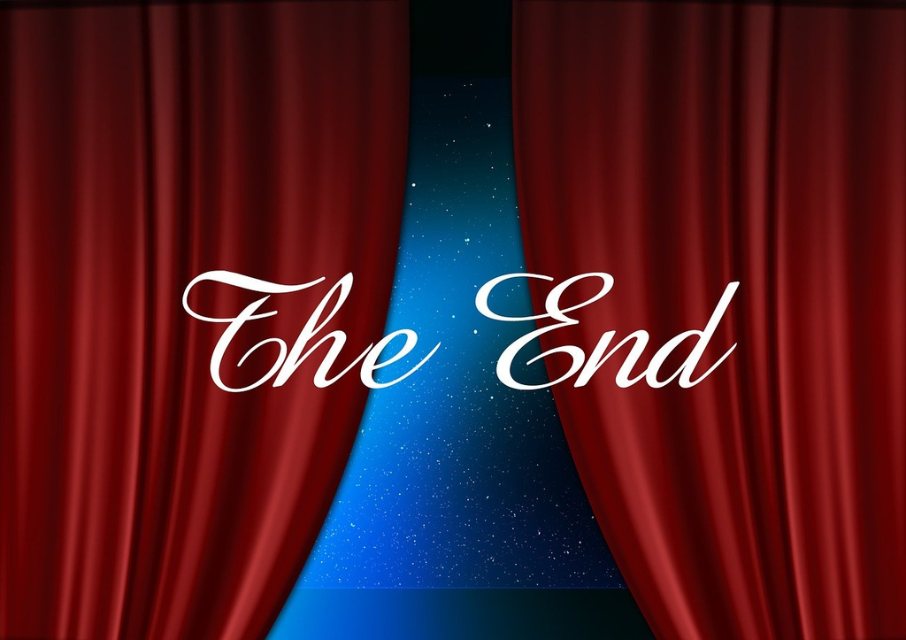

Image by [Gerd Altmann](https://pixabay.com/users/geralt-9301/?utm_source=link-attribution&utm_medium=referral&utm_campaign=image&utm_content=812226) from [Pixabay](https://pixabay.com//?utm_source=link-attribution&utm_medium=referral&utm_campaign=image&utm_content=812226)